# Doing Better Informatics Faster

A Visual CV

Chris Tastad

## Table of Contents

1. Professional Profile
2. Cloud Architecture & Infrastructure
3. Genomic Software Development
4. Production Software & APIs
5. FAIR Data Standards & Reproducibility
6. People Management
7. Technical Expertise
8. The Random Walk —

### Technical Deep Dives

- **prep-sopa:** HPC execution wrapper for the Sopa spatial omics pipeline
- **Parallax:** Nextflow DSL2 spatial differential expression pipeline
- **IDhub:** PostgreSQL + REST API ID harmonization platform
- **nf-core Minerva profile:** Institutional HPC execution configuration

## Contact

- **Email:** ctastad@gmail.com
- **LinkedIn:** linkedin.com/in/ctastad
- **GitHub:** github.com/ctastad
- **Phone:** (612) 817-7989
- **Location:** HQ in NYC | Based out of MPLS, MN

**Download Full CV:** https://github.com/ctastad/cv

# Professional Profile

## Who I Am

- Bioinformatics engineer and team leader bridging genomic science with production-grade software and infrastructure
- Currently in a role where I wear many hats
- Experience of 10+ years spanning wet lab, computational biology, cloud architecture, and people management
- Track record of introducing enterprise practices: reproducibility, FAIR standards, CI/CD, containerization
- Strength in the gestalt: connecting technical decisions to scientific outcomes and organizational strategy

## Fit Check

### What I Bring

- A diversity of technical and soft skills that can be adapted across a broad range of contexts
- Fluency operating as both an individual contributor and a people leader
- A track record of doing the boring stuff well
- The choice to elevate the people around me as a deliberate practice

### What I’m Looking For

- Mission-driven science and enterprise
- Resources that provide opportunities to push limits of scaling
- Strong team dynamics that reinforce the technical domain and foster success
- The flexibility to optimise and shape process to serve that mission

## Guiding Principles

### How I approach the work

- Every technical decision is also a resource decision. Good engineering, science, or leadership are inseparable from good economics
- Enterprise best practices belong in research environments
- If we have to get dogmatic about something it should be reproducibility and statistical rigor
- Solutions sized to actual requirements. Pragmatic over fashionable, right-sized instead of over-engineered
- Straightforward honesty about tradeoffs, timelines, and limitations; trust is built on clarity, not optimism

## Professional Summary

### Bridging Software Engineering & Genomics

- **Cloud & On-prem Architecture:** Fully architected AWS enterprise infrastructure (EC2, S3, RDS, VPC, IAM, ECR), self-built and managed nodes
- **Genomic Platforms:** Single-cell, spatial transcriptomics, WGS/WES pipelines, multi-omics
- **Software Development:** Python, R, Nextflow, CI/CD, REST APIs, code and data versioning
- **Environment Management:** Custom built hardware, containerized dev envs, web services to fit needs
- **Data Scale:** 0.5PB+ genomic datasets, 650+ global collaborators

## Career at a Glance

**2007–2013:** Research Associate

*Wet lab beginnings — foundations of science*

**2016–2017:** Graduate Research Assistant - NMDP

*HLA typing, immunogenomics → computational transition*

**2019–2021:** Graduate Research Assistant - University of MN

*Cancer genomics, single-cell, beginning of community tool dev*

**2021–2023:** Bioinformatician II - Mount Sinai, Cho Lab

*Total ownership of compute methods, reshaping team science philosophy*

**2021–Present:** Lead Data Engineer - IBDGC

*Intro cloud architecture, complete renovation of 20-year project infra*

**2023–Present:** Senior Manager, Bioinformatics - Mount Sinai, Cho lab

*Established leadership, 5 reports, consultation across all projects, maturation of strategic planning, design, and solutions, exponential scaling*

## Questions - off ramp

## Innovations

### New capabilities introduced where none previously existed

- **Cloud infrastructure** — first AWS migration for a 20-year consortium project previously running on-prem
- **Standardized analysis** — unified, containerized framework replacing half a dozen ad-hoc team workflows
- **Distributed compute** — Nextflow-based pipeline execution across HPC and cloud, replacing serial single-machine patterns
- **Reproducible environments** — renv, Docker, and CI/CD introduced to teams running unversioned local-only stacks
- **Automated cell annotation** — reference-based and ML-driven labeling (CellTypist, scANVI) replacing manual assignment
- **GPU-accelerated workflows** — RAPIDS/scVI tooling established for teams running entirely CPU-bound pipelines
- **Knowledge management** — Confluence/Jira implemented across a consortium running on undocumented institutional memory
- **FAIR data distribution** — structured, auditable release workflows replacing ad hoc data sharing

## Key Achievements

### Quantifiable Outcomes

- **Architected** enterprise AWS infrastructure supporting 0.5PB+ genomic and clinical datasets
- **Built** $60K+ on-prem compute infrastructure expanding non-technical team compute capacity dramatically
- **Developed** novel spatial transcriptomics methodologies (Parallax, extension of Sopa, Novae)
- **Created** standardized single-cell frameworks adopted across 12+ projects
- **Engineered** ID harmonization platform unifying 20 years of longitudinal data
- **Achieved** zero data loss incidents over 5+ years of data management
- **Selected** as 10x Genomics beta partner for spatial platform development
- **Wrote** open-source nf-core institutional execution profile for community
- **Optimized** costs by replacing $250K+ annual vendor contracts with open-source solutions
- **Contributed** to $9.5M+ in grants through technical leadership and experimental design

# Cloud Architecture & Infrastructure

## AWS Enterprise Genomic Platform

### Infrastructure Scale

- 0.5PB+ genomic data (S3/Glacier)
- EC2 compute clusters with auto-scaling
- VPC networking with WAF security
- Multi-domain hosting (ibdgc.org, ibdgenetics.org)
- **Cost Reduction:** Optimized data life cycle policies, resource allocations, and spending plans for 50% reduction across cloud budget
- Use of AWS batch across nc-core execution profiles and nftower

### Data Governance

- HIPAA-compliant PHI isolation
- 3-2-1 backup paradigm
- Zero data loss incidents (5+ years)
- Cross-institutional collaboration frameworks

### Key Components

- Leverage of low-cost solutions across DNS and web hosting
- Secure VPC with public/private subnets
- S3 buckets with lifecycle policies (Standard → Glacier)
- EC2 Auto Scaling groups for compute workloads
- IAM roles with least-privilege access
- CloudWatch monitoring and alerting

## On-Premises Compute Expansion

**Strategic Infrastructure Investment**

### The Build

- Sourced, built, and deployed purpose-built **$60K+ on-premises supplementary compute infrastructure**
- Custom node configuration optimized for memory-intensive genomic workloads
- Strategic vendor negotiations to maximize hardware value
- Integrated into cloud-HPC-hybrid architecture alongside existing AWS footprint

### Impact

- **3x expansion** in team computational capacity
- Fraction of cost compared to equivalent commercial cloud alternatives
- Seamless HPC/cloud hybrid workflow execution
- Custom performance tuning for bioinformatics pipelines

## On-Premises Architecture

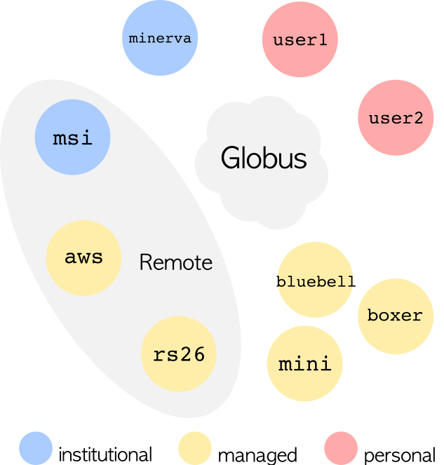

**Technical Specifications**

- Custom node builds for high-memory, flexible, multimodal genomic workloads
- High-speed NFS storage fabric with redundant paths
- Network-attached storage integrated with S3 sync
- High throughput cross node workflow and data transfer via Globus

## On-Premises Architecture

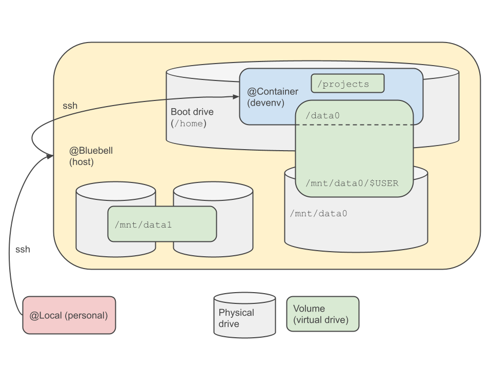

- User-specific, recomposable, containerized dev environments
- Specialized management of complicated R dependencies
- Accessible docs and implementation for Biologists

## On-Premises Architecture

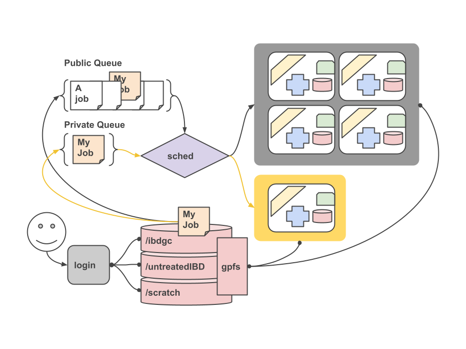

- One node integrated directly with HPC network and GPFS
- Priority queue to our users and collaborators

# Genomic Processing Development

## CoreSC: Standardized Single-Cell Framework

### Challenge

- Ad-hoc analysis methods across 12+ projects
- Inconsistent statistical methodologies
- Fragmented reproducibility across international consortia

### Solution

- Unified preprocessing paradigm (R/Seurat)
- Containerized deployment (Docker/Singularity)
- renv lockfiles for reproducible environments
- Adopted across all internal projects
- **Result:** Eliminated analysis inconsistencies, accelerated discovery for non-technical biologists

## CoreSC Framework Architecture

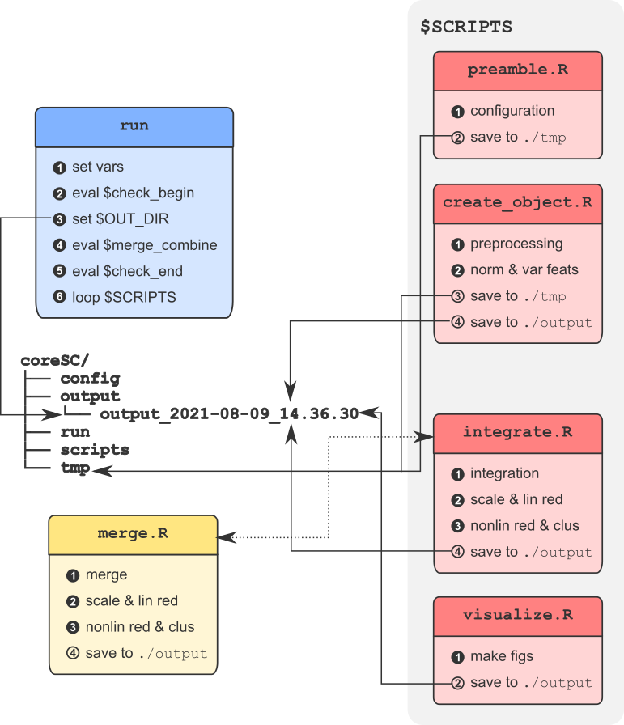

### Technical Implementation

- R/Seurat for single-cell analysis with SCTransform v2
- renv for reproducible package environments
- Docker containers for portable deployment
- Automated reporting and QC gates

## CoreSC Framework Architecture

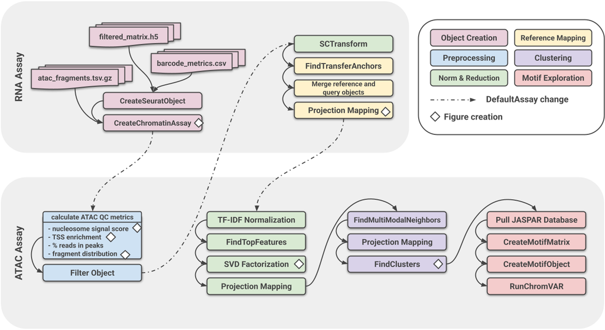

**Technical Implementation**

- Expanded to handle multi-omic single cell data across ATAC and CITE-seq
- Flexible subroutine execution
- Improved capacity for parallelization

## Spatial Transcriptomics Pipelines

**Novel Methodology Development | 10x Genomics Beta Partner**

### Innovation

- Extended Sopa framework for comprehensive Xenium processing and integration of domain-based processing and scalable execution
- Context-aware spatial differential expression analysis through self-built Parallax pipeline
- Annotation noise correction algorithms for Visium/Xenium
- Multi-sample integration workflows via Novae

### Industry Partnership

- **10x Genomics Beta Partner** – Cloud hosting feature development for Xenium Explorer
- Direct product roadmap influence and feedback integration on Explorer cloud integration
- Institution-first full Xenium deployment (advised on custom power, complete institutional security review, networking implementation)
- Spatial transcriptomics best practices development

## Spatial Analysis Pipelines - Sopa

[figure not shown]

- Contributed LSF compatible implementation
- Extended to include spatial domain assignment workflow
- Wrote extensive run prep workflow to deal with high volume independent sample execution

> *Blampey, Q., Mulder, K., Gardet, M. et al. Sopa: a technology-invariant pipeline for analyses of image-based spatial omics. Nat Commun 15, 4981 (2024). https://doi.org/10.1038/s41467-024-48981-z*

## Spatial Analysis Pipelines - Parallax

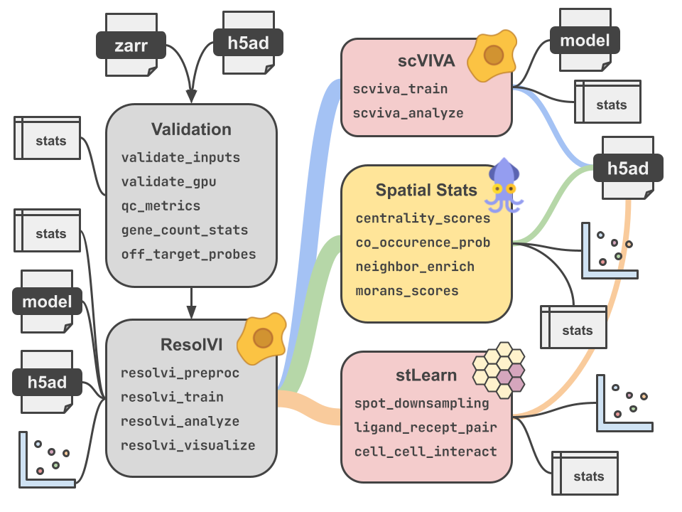

**Technical Implementation**

- In-house Nextflow pipeline built on Nextflow DSL2
- Pushes spatial preprocessing further downstream into analysis
- Leveraging bleeding edge variational inference methods from scVI
- Capable of training in distributed GPU array

## Spatial Analysis Pipelines - Parallax

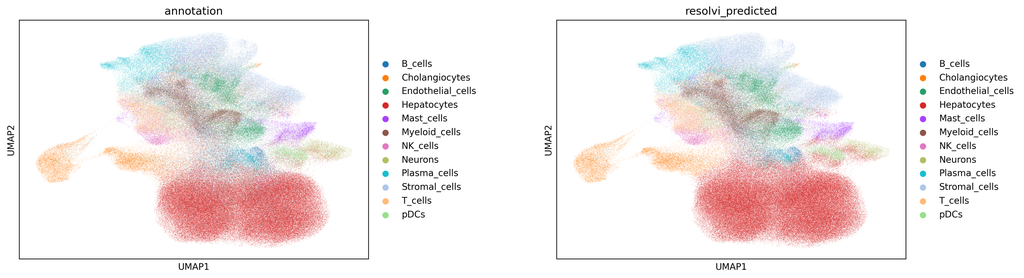

## Spatial Analysis Pipelines - Parallax

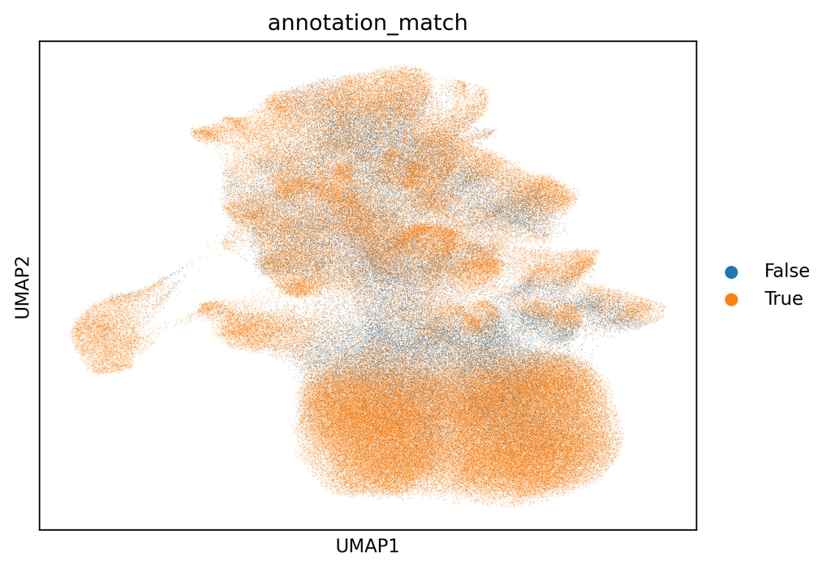

## nf-core & Open Source Contribution

**Institutional Standards Development**

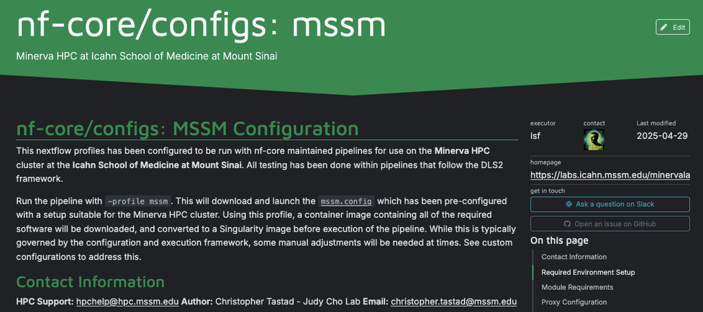

**Community Impact**

- Developed **official Mount Sinai execution profile** for nf-core pipelines
- Standardized HPC configuration (LSF integration)
- CI/CD deployment via GitHub Actions with automated testing

```bash
/*
~~~~~~~~~~~~~~~~~~~~~~~~~~~~~~~~~~~~~~~~~~~~~~~~~~~~~~~~~~~~~~~~~~~~~~~~~~~~~~~~~~~~~
    Nextflow config for Minerva HPC at Icahn School of Medicine at Mount Sinai
~~~~~~~~~~~~~~~~~~~~~~~~~~~~~~~~~~~~~~~~~~~~~~~~~~~~~~~~~~~~~~~~~~~~~~~~~~~~~~~~~~~~~
    Author: Christopher Tastad - Judy Cho Lab
    Contact: christopher.tastad@mssm.edu
    HPC Support: hpchelp@hpc.mssm.edu

    IMPORTANT: Before running this pipeline, set the MINERVA_ALLOCATION environment
    variable in your master submission script:

    export MINERVA_ALLOCATION="acc_YOUR-PROJECT-NAME"

~~~~~~~~~~~~~~~~~~~~~~~~~~~~~~~~~~~~~~~~~~~~~~~~~~~~~~~~~~~~~~~~~~~~~~~~~~~~~~~~~~~~
*/

// Global default params
params {
    config_profile_description = 'Minerva HPC at Icahn School of Medicine at Mount Sinai'
    config_profile_contact     = 'Christopher Tastad (@ctastad)'
    config_profile_url         = 'https://labs.icahn.mssm.edu/minervalab/'

    // Cluster-specific parameters
    minerva_allocation         = System.getenv('MINERVA_ALLOCATION') ?: 'default_allocation'
    max_cpus = 64
    max_memory = '1.5.TB'
    max_time = '336.h'
}


// Singularity configuration
env {
    SINGULARITY_CACHEDIR = "/sc/arion/work/${System.getenv('USER')}/singularity_cache"
    SINGULARITY_TMPDIR = "/sc/arion/work/${System.getenv('USER')}/singularity_tmp"
    SINGULARITY_LOCALCACHEDIR = "/sc/arion/work/${System.getenv('USER')}/singularity_cache"
    SINGULARITY_PULLFOLDER = "/sc/arion/work/${System.getenv('USER')}/singularity_cache/pull"
    SINGULARITY_DISABLE_CACHE = "no"

}

singularity {
    enabled = true
    autoMounts = true
    cacheDir = "/sc/arion/work/${System.getenv('USER')}/singularity_cache"
    pullTimeout = '120 min'

    // Pass proxy settings to container
    envWhitelist = ['http_proxy', 'https_proxy', 'all_proxy', 'no_proxy']
}


// LSF executor configuration
executor {
    name = 'lsf'
    submitRateLimit = '2 sec'
    // Specific LSF settings for proper memory handling
    perJobMemLimit = false
    perTaskReserve = true
    max_time = '336.h'
}

// Process configuration
process {
    executor = 'lsf'
    resourceLimits = [
        cpus: 64,
        memory: 1.5.TB,
        time: 336.h
    ]

    // Dynamic queue selection based on job requirements
    queue = {
        if (task.time > 144.h) {
            return 'long'
        } else if (task.label && task.label.toString().contains('gpu') && task.time <= 30.min) {
            return 'gpuexpress'
        } else if (task.label && task.label.toString().contains('gpu')) {
            return 'gpu'
        } else if (task.time <= 12.h && task.cpus <= 8) {
            return 'express'
        } else {
            return 'premium'
        }
    }

    // Cluster options with proper memory handling
    clusterOptions = {
        def options = "-P ${System.getenv('MINERVA_ALLOCATION') ?: params.minerva_allocation}"

        // Handle memory requests - ensure consistency between -M and rusage
        if (task.memory) {
            def mem = task.memory.toMega()
            options += " -M ${mem}"
        }

        // Add GPU-specific options
        if (task.label && task.label.toString().contains('gpu')) {
            def gpuNum = task.label.toString().contains('high_gpu') ? 2 : 1
            options += " -gpu num=${gpuNum}"
        }

        return options
    }

    // Add gpu awareness to container
    withLabel: 'gpu|.*gpu.*' {
        containerOptions = '--nv'
    }

    // ERROR HANDLING CONFIGURATION
    // Default dynamic error strategy for most processes
    errorStrategy = {
        if (task.exitStatus in [130, 137, 140] && task.attempt <= 3)
            return 'retry'
        else if (task.exitStatus in [131..145] && task.attempt <= 1)
            return 'retry'
        else
            return 'finish'
    }
    maxRetries = 3

    // Special error handling labels (these override the dynamic strategy above)
    withLabel:error_ignore {
        errorStrategy = 'ignore'
        maxRetries = 0
    }

    withLabel:error_retry {
        errorStrategy = 'retry'
        maxRetries = 2
    }

    // Set default failOnMissingField behavior (optional)
    shell = ['/bin/bash', '-euo', 'pipefail']
}
```

# Production Services & Interfaces

## IDhub: ID Harmonization Platform

### System Architecture

- PostgreSQL database with REST API
- Global Subject ID resolution service
- Multi-staged curation workflows
- Audit logging & lineage tracking
- Included MCP server interface for planned expansion to sample-data LLM integration
- User friendly web GUI for interactive queries

### Impact

- Unified 20 years of consortium recruitment data
- Central source of truth for longitudinal studies
- Automated metadata management (LabKey LIMS API)
- **FAIR-compliant**

## IDhub Workflow Diagram

[figure not shown]

## Bystro: Genomic Annotation Platform

**High-Performance Annotation on the Web**

### Performance Transformation

- Chosen as beta partner by Bystro AI for self-hosted deployment
- **Challenge:** WES/WGS annotation required days of processing with limited accessibility
- **Solution:** Deployed ultra-fast, web-based, cloud-hosted annotation service in AWS
- **Impact:** Reduced processing time from **days → hours**
- Significant accessiblity to non-technical users and in publication hosting

## REDCap-Booster & Data Automation

**Metadata Management Systems**

### Automation Stack

- Python/R automation utilities for ETL processes
- LabKey sample management API integration
- REDCap API for clinical data capture
- Sanitization and curation frameworks for clinical metadata harmonization

### Operational Impact

- Massive reduced manual curation overhead
- Systematic data stewardship protocols
- Cloud-hosted automated subject identification
- 20-year longitudinal study support with maximized data lineage

## Data Automation Pipeline

[figure not shown]

**Integration Points**

- REDCap API for clinical data capture
- LabKey API for biospecimen tracking
- Automated quality checks and validation rules
- Cloud storage synchronization with S3
- Audit logging for compliance tracking

# FAIR Data Standards & Reproducibility

## FAIR at the Consortium Level

### Findable & Accessible — IBDGC

> 650+ global collaborators, 20 years of longitudinal data

**Findable & Accessible**

- FAIR and NIH-compliant data distribution via Open Science Framework, replacing ad hoc sharing
- IDhub REST API with full audit logging as foundational data integrity infrastructure
- All core systems expose structured interfaces, reducing manual intervention for non-technical users

## FAIR at the Consortium Level

### Interoperable, Reusable & Right-Sized — IBDGC

**Interoperable & Reusable**

- Harmonized subject IDs unifying 20 years of legacy data across REDCap, LabKey, and institutional databases
- 3-2-1 backup paradigm with zero data loss incidents over 5+ years
- Git version control across all pipeline code; data versioning via DVC with S3-backed registries

**Right-Sized by Design**

- Replaced complex tooling with interface-driven, API-accessible workflows for non-technical users
- Saved an R01 equivalent in hosting costs by right-sizing infrastructure to actual community requirements

## FAIR for Reproducibility

### Policies & Frameworks — Cho Lab

> Enterprise reproducibility standards introduced where unversioned, local-only workflows previously dominated
- **CoreSC** unified containerized single-cell preprocessing with renv lockfiles, eliminating analysis inconsistency across 12+ projects
- **DVC** project-specific data registries with S3 storage lifecycle management
- **CI/CD via GitHub Actions** automated deployment and testing for code and data pipelines
- **nf-core institutional profile** standardized HPC execution configuration

## FAIR for Reproducibility

### Tools & Practices — Cho Lab

- **Containerized** reproducible environments for non-technical HPC users, replacing local-only unversioned stacks
- **renv** R environment lockfiles introduced across teams with no prior dependency management
- **GitHub** enforced version control adoption across team and consortium
- **Confluence/Jira** institutional knowledge management replacing undocumented institutional memory; SOPs and decisions made searchable and persistent

## FAIR Principles Alignment

### Mapping practices across both contexts

| Principle | Implementation |
| --- | --- |
| **Findable** | IDhub global subject resolution; OSF structured data releases; Confluence knowledge base; DVC data registries |
| **Accessible** | REST APIs (IDhub, Bystro); web-based annotation platform; standardized data distribution workflows; nf-core public profile |
| **Interoperable** | Harmonized IDs across 20 years of legacy systems; nf-core standard profiles; containerized environments; REDCap/LabKey API integration |
| **Reusable** | renv lockfiles; DVC registries; CoreSC framework; CI/CD pipelines; audit logging; Docker containers; documented SOPs |

# People Management

## Team Leadership

### Management Innovation

- Lead **5-person bioinformatics team** across 12+ concurrent multi-year projects
- Lead **4-person data team** for Data Coordinating Center of NIDDK IBD Genetics Consortium across infrastructure and data archival responsibilities
- Flexible **Agile methodologies:** Daily stand-ups, weekly office hours, data round tables
- Recruitment, screening, technical assessment, and knowledge transfer protocols
- Quarterly workload assessments & roadmap planning with principal investigators

## Knowledge Management & Institutional Memory

### Organizational Systems Development

**Implementation**

- Established organizational knowledge management implementing **Atlassian services (Confluence/Jira)** across team and consortium
- Deployed and managed Google Workspace services for inter-institutional communication and organization
- Rigorous information organization standards and documentation taxonomy
- Onboarding systems reducing new contributor ramp-up time
- Enforcement of wide-spread use of code and data version control systems

**Impact**

- Consistent project tracking across 12+ simultaneous initiatives
- Consortium-wide visibility into project status and deliverables
- Searchable institutional knowledge base (SOPs, protocols, decisions)
- Reduced knowledge silos and single-point-of-failure personnel risk

## AI-Assisted Development Infrastructure

**Implementation**

- Deployed **Sourcegraph** enterprise platform for secure team LLM access
- Pioneered AI-assisted development tools in bioinformatics workflows
- Established institutional standards for responsible AI adoption
- Tech lead on methodological innovation (dozen+ major initiatives)

**Impact**

- Accelerated code review and documentation processes
- Standardized prompt engineering for genomic analysis
- Secure, HIPAA-compliant AI tool deployment
- Measurable team productivity improvement

# The Random Walk

## Experience That is Difficult to Categorize

### The Roles

- **Lobbyist** – Stakeholder priorities, coalition building, bureaucratic process navigation
- **UPS Operations** – Logistics systems, high-pressure throughput, operational accountability
- **Manual & Farm Labor** – Physical discipline, grunt work, real-time execution
- **Health Care** – emergency and perioperative patient care, precision under pressure, human stakes behind clinical data

### Transferable Skills

- Communication that works across every audience
- The ability to do hard, unglamorous things without complaint
- Respect for operational complexity at every level of an organization
- Translating technical work for non-technical decision makers
- Comfort with ambiguity, durability under pressure, execution focus
- Empathy for people of all stations
- The diplomacy to navigate challenging work environments

# Deep Dive - prep-sopa

## prep-sopa: Sopa Execution Wrapper

### Spatial Pipeline Orchestration on HPC

**Challenge**

- Sopa is a powerful, technology-invariant spatial omics framework, but raw execution on HPC requires non-trivial environment management, LSF configuration, and per-sample parameterization
- Running high-volume independent Xenium samples without a wrapper creates brittle, manual, non-reproducible submission patterns
- Non-technical users in the lab had no path to independent execution

**Solution**

- `prep-sopa` — a purpose-built Python orchestration tool that **generates** fully parameterized LSF submission scripts rather than running the pipeline directly
- Abstracts environment complexity, HPC configuration, and output structure behind a single CLI invocation
- Enforces reproducibility by design: every run produces config backups, parameter logs, and timestamped output directories

> *Wraps: Blampey, Q., Mulder, K., Gardet, M. et al. Sopa: a technology-invariant pipeline for analyses of image-based spatial omics. Nat Commun 15, 4981 (2024). https://doi.org/10.1038/s41467-024-48981-z*

## prep-sopa: Execution Architecture

### Design Pattern: Code Generation over Direct Execution

```bash
# Single CLI call per sample — all complexity abstracted
conda activate prep-sopa

python main.py \
  --id [panel_id]/[run_id] \
  --config-name [config.yaml] \
  --project-dir [project_directory]
```

**What happens under the hood**

1. Validates Xenium data location and filtered transcript availability (`qv20-filtered-transcripts`)
2. Resolves environment paths across `prep-sopa` and `sopa2` conda envs + Baysor executable
3. Reads and validates YAML config against expected schema
4. **Generates** per-sample LSF submission scripts with correct memory, queue, and path bindings
5. Writes scripts to `lsf_scripts/`, ready for `bsub` submission with no further editing

```bash
# Generated output — submit without modification
cd oba-outputs/RUN_ID/lsf_scripts
bsub < submit_SAMPLE_NAME.lsf
```

## prep-sopa: Output Contract & Reproducibility

### *Every run produces a fully auditable, self-contained output structure

```
xenium-registry/sopa/project_dir/
├── timestamped_run_dir/         # Unique per execution — no overwrites
│   ├── explorer/                # Xenium Explorer-compatible outputs
│   ├── *.zarr                   # SpatialData Zarr store
│   ├── params.log               # Full parameter record
│   ├── config_backup.yaml       # Exact config used for this run
│   └── logs/
│       ├── stdout.log
│       └── stderr.log
```

**Why this matters**

- Timestamped dirs make every run independently addressable, no silent overwrites
- Config backups mean any result can be exactly reproduced from the archived record
- Parameter logs feed directly into downstream provenance tracking
- Zarr + Explorer outputs satisfy both programmatic (Python/R) and interactive (Xenium Explorer) access patterns
- Structure is consistent across all samples, enabling batch result aggregation without path negotiation

# Deep Dive - Parallax

## Parallax: Niche-Aware Spatial DE Pipeline

> A Nextflow DSL2 pipeline that takes SpatialData Zarr stores from Sopa and produces niche-aware spatial differential expression results via coupled variational inference models

**Challenge**

- Sopa produces clean, segmented spatial data, but stops short of differential expression analysis
- Standard DE methods ignore spatial context: which cells are neighbors, what niche they occupy
- No existing tool combined noise correction, cell type prediction, and niche-aware DE in a single reproducible pipeline

**The Design Decision**

- Dual-method architecture: **ResolVI** for noise correction and cell type prediction feeding directly into **scVIVA** for niche-aware DE
- Implemented as Nextflow DSL2, portable across HPC and cloud, resumable, containerized
- GPU-accelerated model training via distributed array; CPU fallback available via profile flag

## Parallax: Execution Architecture

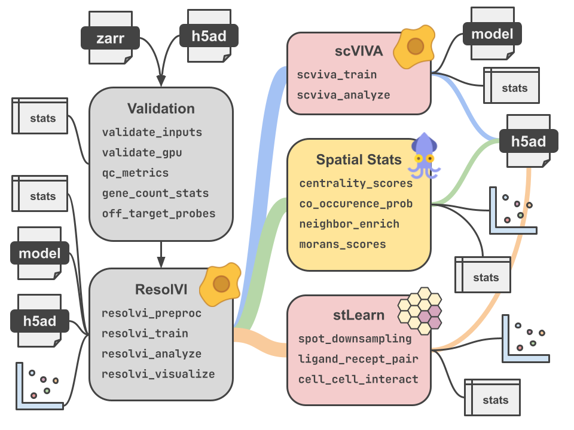

- Modularity means any stage can be rerun independently via Nextflow `-resume` without reprocessing upstream steps
- Singularity containers enforce identical execution on HPC, cloud, or local, no environment drift
- GPU mode resolved at runtime from execution profile, no hardcoded resource assumptions

## Parallax: Module Architecture

**Subroutines and modules

**ResolVI Subworkflow**

| Module | Role |
| --- | --- |
| `VALIDATE_INPUTS` | Schema validation against `nextflow_schema.json`; emits validated channel or fails fast with structured error |
| `RESOLVI_PREPROCESS` | Converts SpatialData Zarr store to AnnData; filters, normalizes, and structures input for model training |
| `RESOLVI_TRAIN` | Trains deep generative model for technical noise correction; emits `model` and `adata` as named output channels |
| `RESOLVI_ANALYZE` | Joins model + adata by sample meta; computes differential abundance and spatial niche composition |
| `RESOLVI_VISUALIZE` | Consumes trained AnnData; generates UMAP embeddings, spatial overlays, annotation comparison plots |

**scVIVA Subworkflow**

| Module | Role |
| --- | --- |
| `SCVIVA_TRAIN` | Consumes ResolVI `model` and `adata` channels directly; trains variational model incorporating cell-intrinsic and neighbor expression context |
| `SCVIVA_ANALYZE` | Joins scVIVA model + trained AnnData by sample meta; produces niche-aware DE results per comparison spec |

**Supporting infrastructure**

| Component | Role |
| --- | --- |
| `bin/check_gpu_availability.py` | Runtime GPU interrogation, validates CUDA availability before training processes launch |
| `bin/validate_gpu_params.py` | Ensures GPU parameter consistency across profile and process label definitions |
| `lib/ChannelUtils.groovy` | Shared Groovy utilities for channel manipulation across subworkflows |
| `lib/WorkflowParallax.groovy` | Pipeline-level workflow helpers and summary logging |
| `MULTIQC` | nf-core module; collects `ch_versions` from every process to produce software provenance report |

## Parallax: Channel Topology & Runtime Logic

**How data flows**

**Input channel construction**

```
ch_input = Channel
    .fromPath(params.input)
    .splitCsv(header: true)
    .map { row ->
        if (!row.sample_id) error "Missing sample_id in row: ${row}"
        if (!row.zarr_path)  error "Missing zarr_path in row: ${row}"

        def meta = [
            id:          row.sample_id,
            condition:   row.condition ?: 'unknown',
            batch:       row.batch     ?: 'batch1',
            single_cell: true
        ]
        [meta, file(row.zarr_path, checkIfExists: true)]
    }
```

**Inter-subworkflow join**

```
ch_resolvi_analysis = RESOLVI_TRAIN.out.model
    .join(RESOLVI_TRAIN.out.adata, by: 0)
    .map { meta, model_dir, adata ->
        if (!model_dir || !adata) error "Missing files for sample ${meta.id}"
        [meta, model_dir, adata]
    }

SCVIVA_TRAIN(
    RESOLVI_TRAIN.out.model,
    RESOLVI_TRAIN.out.adata,
    params.scviva_max_epochs,
    gpu_mode
)
```

**GPU mode resolved from profile at workflow start, not per-process**

```
// Single resolution point, propagated to all training processes as a param
def gpu_mode = workflow.profile.contains('cpu') ? false : true
```

- Fail-fast validation at channel construction surfaces input errors before any compute is consumed
- `ch_versions` mixed from every module output feeds directly into MultiQC, full software provenance captured automatically

## Parallax: Output Contract

**Every run produces a fully auditable, provenance-complete output**

```
OUTDIR/
├── resolvi/
│   ├── corrected_counts.h5ad        # Noise-corrected AnnData
│   ├── cell_type_predictions.csv    # Per-cell type assignments
│   ├── differential_abundance/      # Spatial niche DA results
│   └── plots/                       # UMAP embeddings, spatial plots
├── scviva/
│   ├── niche_de_results.csv         # Niche-aware DE output
│   └── plots/                       # Comparative spatial visualizations
├── pipeline_info/
│   ├── execution_report_TIMESTAMP.html    # Nextflow run report
│   ├── execution_timeline_TIMESTAMP.html  # Per-process timing
│   ├── execution_trace_TIMESTAMP.txt      # Process trace log
│   ├── pipeline_dag_TIMESTAMP.html        # Auto-generated DAG
│   └── software_versions.yml             # Exact tool versions
└── work/                            # Nextflow work dirs
```

# Deep Dive - nf-core Shared Config

## nf-core Minerva Profile: Institutional HPC Configuration

> A community-contributed, dynamically-routing LSF execution profile that makes any nf-core pipeline runnable on Minerva with a single `-profile` flag

**Challenge**

- nf-core pipelines are designed for portability, but raw execution on Minerva (Icahn School of Medicine at Mount Sinai) requires LSF-specific queue routing, Singularity cache management, GPFS path bindings, and allocation accounting that no generic profile provides
- Without an institutional profile, every user configures these independently, producing inconsistent, non-reproducible execution environments across the lab and collaborators
- GPU workloads, long-running jobs, and express queues each require distinct LSF directives that vary by job characteristics, not something a static config can handle

**The Design Decision**

- Author and contribute an **official nf-core institutional profile** merged into the nf-core/configs community repository and available to any Minerva user running any nf-core pipeline
- Dynamic queue and resource routing via Groovy closures rather than static assignments, the config reasons about job requirements at submission time
- CI/CD via GitHub Actions ensures the profile is tested and validated on every update

## nf-core Minerva Profile: Execution Architecture

**Dynamic routing — the config reasons about job requirements at submission time**

```
// Queue resolved per-process based on actual resource requirements
queue = {
    if (task.time > 144.h)                                       { return 'long'       }
    else if (task.label?.contains('gpu') && task.time <= 30.min) { return 'gpuexpress' }
    else if (task.label?.contains('gpu'))                        { return 'gpu'        }
    else if (task.time <= 12.h && task.cpus <= 8)                { return 'express'    }
    else                                                         { return 'premium'    }
}
```

**Memory and GPU directives constructed dynamically per job**

```
clusterOptions = {
    def options = "-P ${System.getenv('MINERVA_ALLOCATION') ?: params.minerva_allocation}"

    if (task.memory) {
        def mem = task.memory.toMega()
        options += " -M ${mem}"
    }

    if (task.label?.contains('gpu')) {
        def gpuNum = task.label.contains('high_gpu') ? 2 : 1
        options += " -gpu num=${gpuNum}"
    }

    return options
}
```

**Key design properties**

- Allocation injected via `MINERVA_ALLOCATION` environment variable, no project codes committed to version-controlled config
- `perTaskReserve = true` / `perJobMemLimit = false` matches Minerva LSF memory accounting model precisely, prevents systematic job rejection
- Singularity cache paths resolved per-user via `System.getenv('USER')`, no shared cache conflicts across users
- `submitRateLimit = '2 sec'` prevents LSF scheduler flooding on large pipeline submissions

## nf-core Minerva Profile: Output Contract & Community Impact

**Error handling — tiered retry strategy covering the full LSF exit code space**

```
errorStrategy = {
    if (task.exitStatus in [130, 137, 140] && task.attempt <= 3)
        return 'retry'
    else if (task.exitStatus in [131..145] && task.attempt <= 1)
        return 'retry'
    else
        return 'finish'
}
maxRetries = 3

withLabel:error_ignore { errorStrategy = 'ignore'; maxRetries = 0 }
withLabel:error_retry  { errorStrategy = 'retry';  maxRetries = 2 }
```

**Resource ceiling enforcement, prevents runaway jobs cluster-wide**

```
resourceLimits = [
    cpus:   64,
    memory: 1.5.TB,
    time:   336.h        // 14-day hard ceiling, maps to LSF long queue max
]
```

**Community impact**

- Merged into the official **nf-core/configs** repository, available to all Minerva users running any nf-core pipeline via `-profile mssm`
- CI/CD via GitHub Actions validates the profile on every commit, institutional config treated as production software
- Eliminates per-user LSF configuration overhead across the lab and all collaborators
- GPU container passthrough (`--nv` Singularity flag) applied automatically via process label. Users do not need to know the flag exists
- Directly enables Parallax, nf-core/rnaseq, nf-core/sarek, and any future nf-core pipeline to run on Minerva without additional configuration

# Deep Dive - IDhub

## IDhub: Federated Subject Identity Platform

> A containerized microservices platform that assigns globally unique subject identifiers across federated clinical sites, resolves cross-center identity conflicts, and provides both programmatic API and no-code curator interfaces over a single PostgreSQL source of truth

**Challenge**

- A multi-site IBD consortium (IBDGC) with dozens of contributing centers produces subject data under heterogeneous local ID schemes
- No shared identity layer meant downstream analyses could not reliably deduplicate subjects across centers
- Non-technical curators needed a path to query, review, and resolve conflicts without writing SQL

**The Design Decision**

- Build a **purpose-designed identity resolution platform** rather than adopting a generic MDM tool
- Microservices architecture: five discrete services each independently deployable, testable, and replaceable: `gsid-service`, `fragment-validator`, `table-loader`, `redcap-pipeline`, `labkey-sync`
- **NocoDB** as a no-code interface layer over PostgreSQL

## IDhub: System Architecture

[figure not shown]

**Two ingestion paths, automated and manual, converge on a single identity resolution service**

- `redcap-pipeline` runs on a schedule via GitHub Actions, clinical data ingested automatically without curator intervention
- `fragment-validator` handles manual curator uploads, field mapping, schema validation, GSID resolution, and conflict detection before anything touches the database
- Both paths route through `gsid-service` for identity resolution, single resolution point, no divergent logic between automated and manual ingestion
- `table-loader` is the commit gate, dry-run by default, explicit `--approve` required to write to the database.
- nginx routes `idhub.ibdgc.org` to NocoDB and `api.idhub.ibdgc.org` to the GSID REST API, with QA and prod environments served from the same compose topology via environment-switched configs

## IDhub: Identity Resolution & Conflict Logic

**GSID format – custom Base32, time-sortable, collision-resistant**

```python
# 21-character format: GSID-TTTTTRRRRRRRRRRR
# T = 5-char Base32 timestamp (ms since epoch mod 32^5) -- roughly sortable
# R = 11-char Base32 cryptographic random -- ~55 bits of entropy
# Custom alphabet excludes I, L, O, U -- eliminates transcription ambiguity

BASE32_ALPHABET = "0123456789ABCDEFGHJKMNPQRSTVWXYZ"

def generate_gsid() -> str:
    timestamp_ms = int(time.time() * 1000)
    timestamp_part = encode_base32(timestamp_ms % (32**5), length=5)
    random_part = encode_base32(secrets.randbelow(32**11), length=11)
    return f"GSID-{timestamp_part}{random_part}"
```

**Center-agnostic matching**

```python
# Match on local_subject_id ALONE -- center_id is NOT part of the match key
# Rationale: the same subject may be registered under different center codes
# across sites; requiring center match would create duplicate GSIDs for the same person

cur.execute("""
    SELECT s.global_subject_id, s.created_at, s.center_id
    FROM local_subject_ids l
    JOIN subjects s ON l.global_subject_id = s.global_subject_id
    WHERE lower(l.local_subject_id) = lower(%s)
""", (identifier["local_subject_id"],))
```

**Three-outcome resolution with full audit trail**

```python
if len(matched_gsids) == 0:
    action = "create_new"         # No match -- mint a new GSID

elif len(matched_gsids) == 1:
    action = "link_existing"      # Single match -- link identifiers to existing GSID
                                  # Center mismatch flagged but does not block resolution

else:
    action = "conflict_resolved"  # Multi-GSID conflict -- same identifier linked to
                                  # different GSIDs (data error) -- use oldest, flag all
                                  # confidence score drops to 0.5, requires_review = TRUE
```

**Every resolution logged to `identity_resolutions`** with confidence score, match strategy, candidate IDs, and matched GSIDs, full adjudication history queryable

## IDhub: Service Architecture & Output

**Five services – discrete responsibilities, shared network, single database**

| Service | Trigger | Role |
| --- | --- | --- |
| `gsid-service` | REST API call | FastAPI service; GSID generation, validation, identity resolution; the only writer to `subjects` and `local_subject_ids` |
| `fragment-validator` | Manual curator invocation | Field mapping, schema validation, GSID resolution, conflict detection; stages to S3; never writes to database directly |
| `table-loader` | Manual with `--approve` flag | Reads validated fragments from S3; dry-run by default; commits to database only on explicit approval |
| `redcap-pipeline` | GitHub Actions schedule | Automated clinical data ingestion; calls `gsid-service` API; writes directly to database via connection pool |
| `labkey-sync` | Scheduled | Syncs specimen metadata from LabKey; updates existing records without creating new subjects |

**Two-phase commit pattern – fragment-validator stages, table-loader commits**

**Conflict adjudication surfaces to curators via NocoDB – not a code change**

- `conflict_resolutions` table written by `fragment-validator`, readable and resolvable via NocoDB UI
- `data_change_audit` records every field modification with `old`/`new` values, `batch_id`, and S3 source path – any change is fully traceable to its source file

## IDhub: Automated Operations via GitHub Actions

Seven workflows cover the full operational lifecycle, from code push to production data integrity.

[output not shown]

### IDhub: Deployment and Environment Management

The `deploy.yml` workflow handles both environments from a single file, with environment-specific secrets resolved dynamically.

```yaml
# Environment and secrets resolved at runtime from branch name or manual input
environment: ${{ github.event.inputs.environment ||
  (github.ref == 'refs/heads/prod' && 'prod' || 'qa') }}

SSH_PRIVATE_KEY: ${{ secrets[format('SSH_PRIVATE_KEY_{0}',
  steps.env.outputs.environment == 'prod' && 'PROD' || 'QA')] }}
```